# Transport trends and development in Switzerland.

Project Report

Luca Bron & Hadrien Lapierre

27 mai, 2018

# 1 Introduction

## 1.1 Overview and Motivation

Last week the “Forum des 100” was held at the University of Lausanne. This year one of the key subject was mobility in Switzerland, and in particular its future. We therefore asked ourselves whether there is a certain trend in the evolution of practices (in terms of passenger transports in particular). We all changed our behavior regarding transportation over the years for various reasons: practical, economic, health, more personal reasons (ecology etc.) or because public authorities have encouraged the use of a particular mean of transport. Now that other means are under study or already in development (flying cars, drones, hyperloop, etc) we are curious to explore the overall situation and behavioral changes of other users in recent years.

The project goal is to have a better understanding of transportation dynamics that exist in our country. We will try to identify correlations and other causal links, particularly with the help of market data analysis. Understanding market past & current behavior helps to define needs, risks and eventually solutions for the future. We believe that having this information in mind can help decision makers.

## 1.2 Related Work

- All strategic information related to [soft mobility (fr)](https://www.astra.admin.ch/astra/fr/home/themes/mobilite-douce/dossiers-strategiques-pour-la-mobilite-douce.html)
- Useful information on road vehicles in Switzerland [on OFS website (fr)](https://www.bfs.admin.ch/bfs/fr/home/statistiques/mobilite-transports/infrastructures-transport-vehicules/vehicules/vehicules-routiers-parc-taux-motorisation.html)
- Motorization rate in Switzerland per year per canton [on OFS website](https://www.bfs.admin.ch/bfs/fr/home/statistiques/mobilite-transports/infrastructures-transport-vehicules/vehicules/vehicules-routiers-parc-taux-motorisation.assetdetail.4402736.html)

## 1.3 Initial Questions

At first, we have defined the following research questions :

- How has the development of public transport affected the use of private vehicles over the years? To what extent?
- What is the link between the investments made in improving public transport networks and the fluctuations in their use?

However, in the course of our analysis we figured the data available to us were not sufficient/precise enough to answer those questions.

In addition, in light of our research and the Forum des 100, we are now convinced that the development of transport and more generally mobility will be largely driven by energy considerations.

**Where do we stand with green mobility in Switzerland? Have awareness, scientific progress, bonus policies for ecological vehicles etc. really impacted our consumption of mobility?** Therefore we adress those questions in this report.

## 1.4 Data

We used data from the Office Fédéral de la Statistique (OFS) mainly :

- Road vehicle fleet by vehicle groups and vehicle types from 1990 to 2017 (retrieved from [OFS website (fr)](https://www.bfs.admin.ch/bfs/fr/home/statistiques/mobilite-transports/infrastructures-transport-vehicules/vehicules/vehicules-routiers-parc-taux-motorisation.assetdetail.4382325.html)). Cleaned up on excel
- Road vehicles put into circulation by vehicle groups and kinds from 1990 to 2017 (retrieve from [ODS website (fr)](https://www.bfs.admin.ch/bfs/fr/home/statistiques/mobilite-transports/infrastructures-transport-vehicules/vehicules/routiers-mises-circulation.assetdetail.4382276.html)). Cleanup on excel
- Transport of people: kilometric allowance and vehicules movement 2005 to 2016 (retrieve from [ODS website (fr)](https://www.bfs.admin.ch/asset/fr/je-f-11.04.01.01) and [ODS website (fr)](https://www.bfs.admin.ch/asset/fr/je-f-11.04.01.01)https://www.bfs.admin.ch/bfs/fr/home/statistiques/mobilite-transports/transport-personnes/prestations.assetdetail.4083125.html). Cleanup on excel

# 2 Exploratory Analysis

## 2.1 Green Mobility in Switzerland

As you will discover in this analysis, we did not cover goods transportation vehicles: according to Mrs Virginie Raisson-Victor from Laboratoire d’études prospectives et d’analyses cartographiques (LEPAC), carbon emissions are more related to the number of passengers rather than freight volume. Moreover, we focused on road vehicles knowing that analyses on rail or air transportation are not relevant to our research question.

To begin with, we looked at passenger cars in Switzerland and particularly their fuel type. We wanted to know if Diesel powered vehicles, the most polluting ones, were declining.  
We can see on the graph below that electric vehicles are gradually making their way onto Swiss roads. Even if the electric proportion in the total number of vehicles put into service remains relatively low, we can see from the following graph that there is indeed a rising trend towards this new mean of propulsion. The data are from the 3903191 cars put into circulation between 2005 and 2017. Our most recent data shows that 16776 electric or hybrid cars were put into circulation i.e. 5.325% of total cars put in circulation in 2017.  
In 2018, OFS published a [press release](https://www.bfs.admin.ch/bfs/fr/home/statistiques/mobilite-transports/infrastructures-transport-vehicules/vehicules/vehicules-routiers-parc-taux-motorisation.assetdetail.4342713.html) which supports our results.

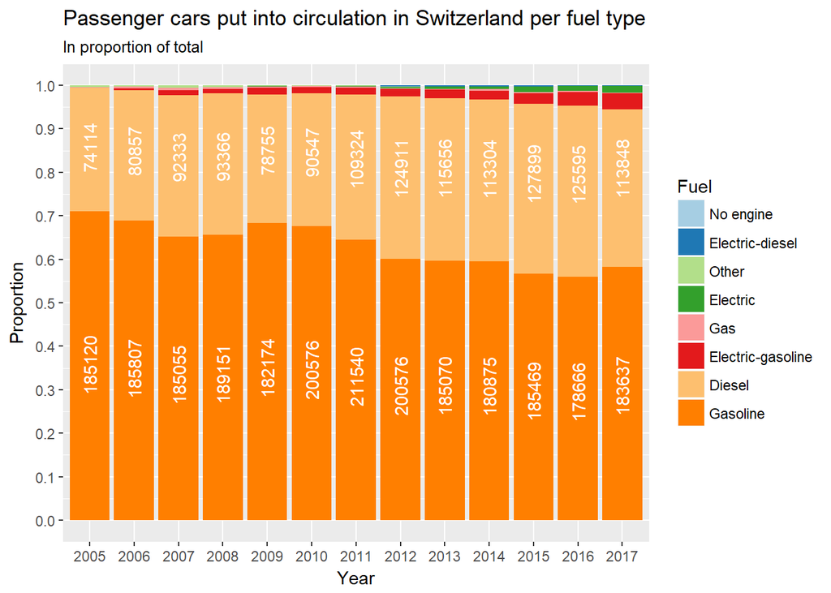

Next, we looked at the car fleet growth to have a more general representation of this evolution: while the growth rate of gasoline car fleet has stagnated for several years, we can see that despite being positive, the evolution of diesel fleet slows down a little more each year. The growth rate of electric vehicles is relatively high since 2009 and demonstrates a booming market. Nevertheless, it should be noted that this very high variation (+60%) between 2012 and 2015 has tended to run out of steam since then, for an increase of “only” 36% in 2017.

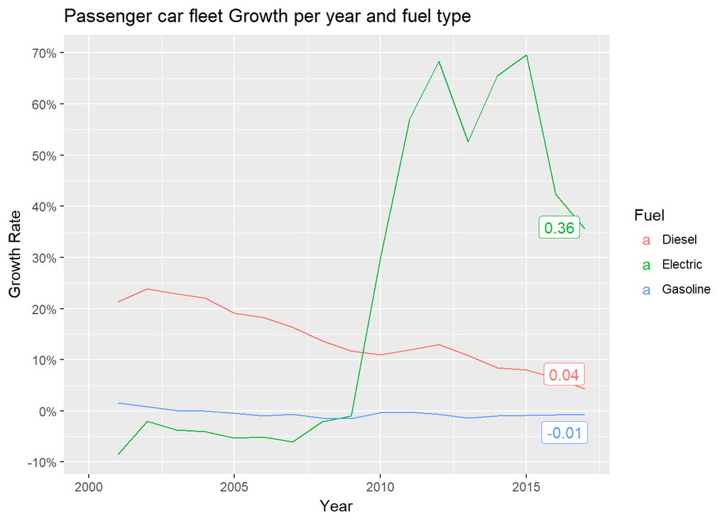

We took a look at the road passenger transport vehicles (light automobiles, heavy automobiles, buses, minibuses) put into circulation in Switzerland for the last decade. Here is the repartition:

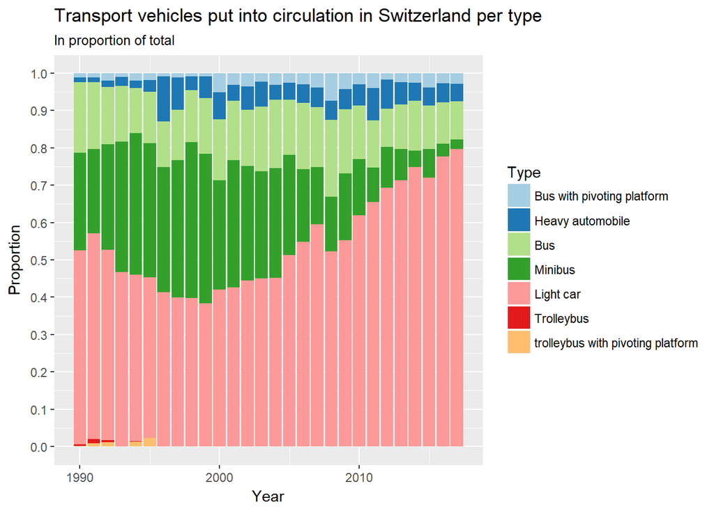

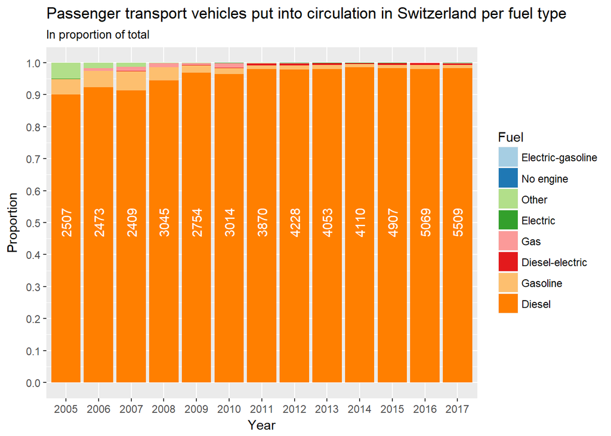

To be honest, these numbers are quite suprising for us. Before looking at these data, we thought that public transportations would be the first to make the energy transition, or at least use less polluting fuel like gasoline (more co2 emissions but far fewer fine particles)! But it appears the cost for hybrid or electric buses and other public transport is still too high to compete with regular diesel.

To go further :

- [After five years of testing, CarPostal gives up fuel cell buses (fr)](https://www.rts.ch/info/suisse/8355006-apres-un-test-de-cinq-ans-carpostal-renonce-aux-bus-a-pile-a-combustible.html)
- [Electric and hybrid buses on Swiss roads (fr)](https://www.ecolive.ch/prestations/climat/projets/suisse-bus/)

In 2016 however, Geneva Public Transportations [placed an order for 100% eclectric buses](https://www.letemps.ch/economie/tpg-passent-commande-bus-100-electriques) for one line only which looks like a test more than a definitive transition. The buses took the road in early 2018 but due to technical issues, [they did not take any passengers this year](https://www.rts.ch/info/regions/geneve/9171449-pas-de-passagers-avant-2018-pour-le-bus-electrique-tosa-a-geneve.html)

For the time being, it would appear that the energy transition for public transports is not imminent.

Finally we will take a look at motorcycles :

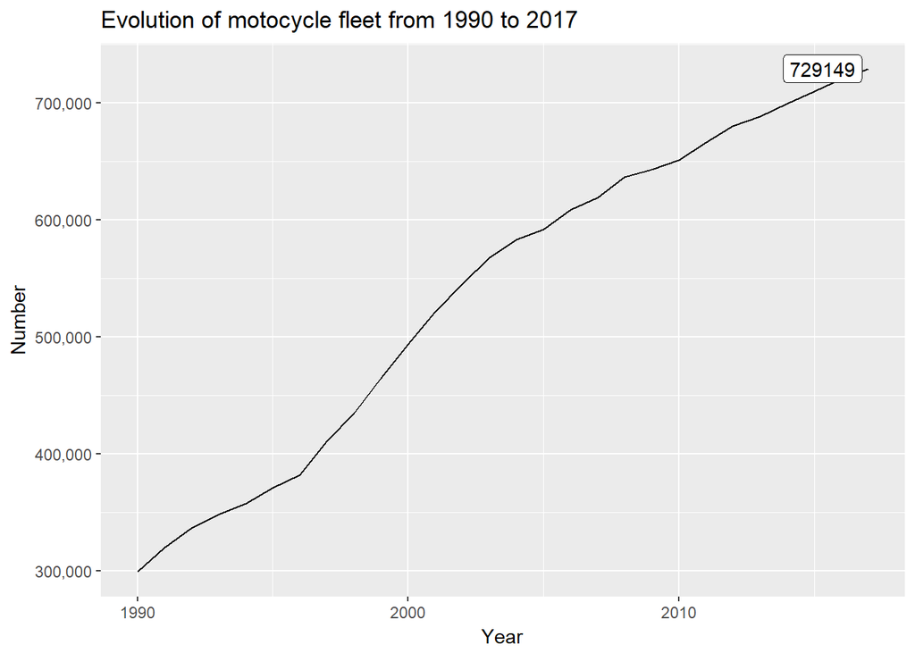

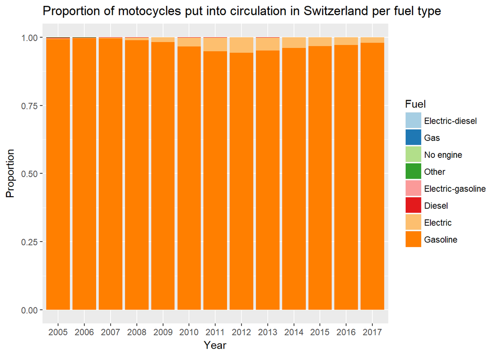

## 2.2 Difference between types of vehicules

Now that we have done some exploratory data analysis on the consumer choice of car engine, we will now look at the tradeoff between taking the car or other means of transportation.

### 2.2.1 Infrastructure and vehicule-kilometer

For this first analysis, we observe the amount of vehicule-kilometer which corresponds in billion to the number of kilometers traveled by each vehicule type.  
This statistic by itself is not the most interesting. It’s like comparing apple to oranges since a car can contain one to six people whereas a train contains hundreds having the distance travelled by a vehicle does not tell much about the user’s behaviour. Here, the first graph show that private car is the main transport by far. However, this statistic is interesting when used to observe trends within each type. It is a good proxy of how the infrastructure and its ecological impact grow. We see that for private car, there’s a need for larger infrastructure.

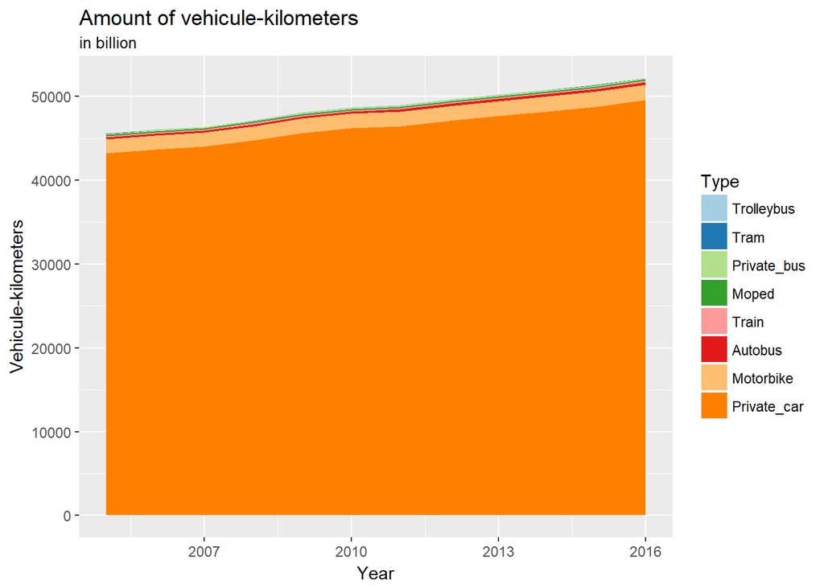

Because of the prevalence of private car, it is hard to see how the other variables do. We thus build a model that use a linear model to generate an estimate of the increase of each transport type per year.

```r
by_transport <- kilometers %>% group_by(Type) %>% nest
#nest by transport type
transport_model1 <- function(df) {lm(Vehic_km ~ Year, data=df)}
#creates the models fitting functions

by_transport1 <- by_transport %>%
  mutate(model = purrr::map(data, transport_model1))
#create a new column for the nested models so that the related objects are stored together

by_transport1 <- by_transport1 %>%
  mutate(predictions = purrr::map2(data, model, add_predictions), resids = purrr::map2(data, model, add_residuals))
#create a new column for the nested predictions and residuals of the model

by_transport3 <- by_transport1 %>%
  mutate(tidy = purrr::map(model, broom::tidy)) %>%
  unnest(tidy, .drop = TRUE) %>%
  filter(term=="Year")
#unnesting the data. Retrieving the coefficients and their statistics
```

Now we can do some analysis.

The first table shows the predicition of the yearly increase for each transportation type. The raw data is the not the most interesting and we’ll talk about relative data further down the line.

Looking at the residuals, it was first needed to be able to compare them between classes. Since Private_car was so big compared to the other, we create a measure of the residuals proportional to their predictors. Looking at the output, we see that the growth is much more stable for cars and trains than for trams.  
Lastly, a graph was made to see if there’s a correlation of the residuals between types of tranportation. If we see a pattern of residuals through all the graphs, that would mean that there were some similare fluctuations in different types at the same time. However, we do not observe this here.

Yearly increase

| Type | Prediction | STDE |
| --- | --- | --- |
| Train | 3.437 | 0.152 |
| Tram | 0.679 | 0.101 |
| Trolleybus | 0.076 | 0.043 |
| Autobus | 4.921 | 0.385 |
| Private_car | 577.918 | 12.952 |
| Private_bus | 1.967 | 0.267 |
| Motorbike | 13.555 | 0.668 |
| Moped | 1.803 | 0.403 |

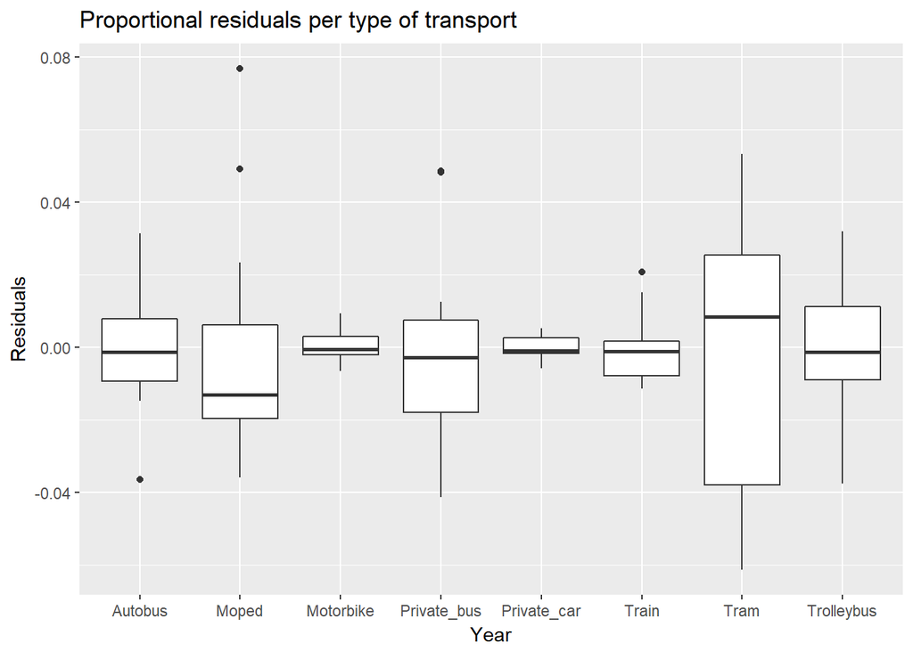

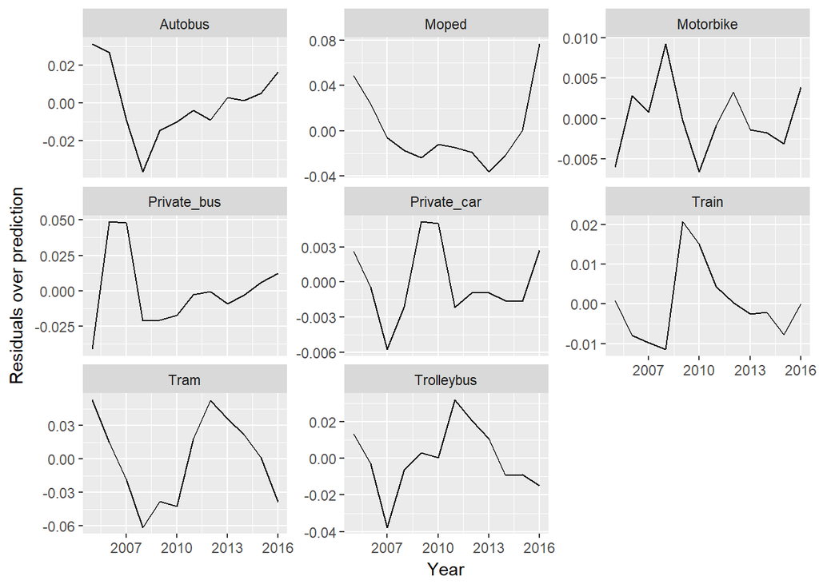

This graph is what we touched upon previously. I shows how much the growth of different types of transport was compared to the other. All variables are set to 100% for year 2005 and we see their relative evolution.  
We can see that train has gained 20% in 11 year while Trolleybus stagnated.

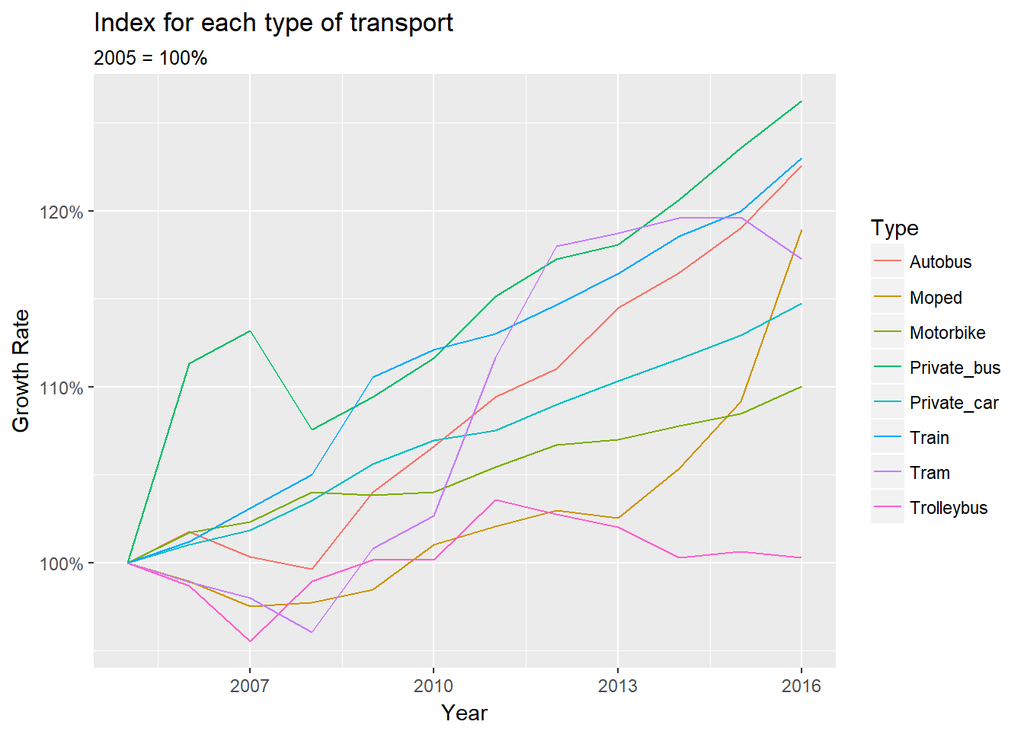

Overall, we see that there’s a need for stronger transport infrastructure in Switzerland. For most of the transportation types, we had an increase of vehicule-kilometers. The good news it that the types that see the strong increase are the most eco-friendly one like train and autobus.

### 2.2.2 Behaviour and person-kilometer

Similarly from the statistic that was used previously, here the analysis is on person-kilometer which is in billion the number of kilometers traveled by people for each vehicule type. Here, the statistic is much more understandable. Instead of having the distance travelled by vehicules, it’s by person. That means no more guess of how many people you can fit in each vehicule type.

First, we wanted to know if there’s a general trend of how much people travel.  
This first graph shows that the people in Switzerland always travel more. In 2016, the number reaches 107’888 billion of person-kilometer. Even though the increase in population size might be for something, it is still a large increase.

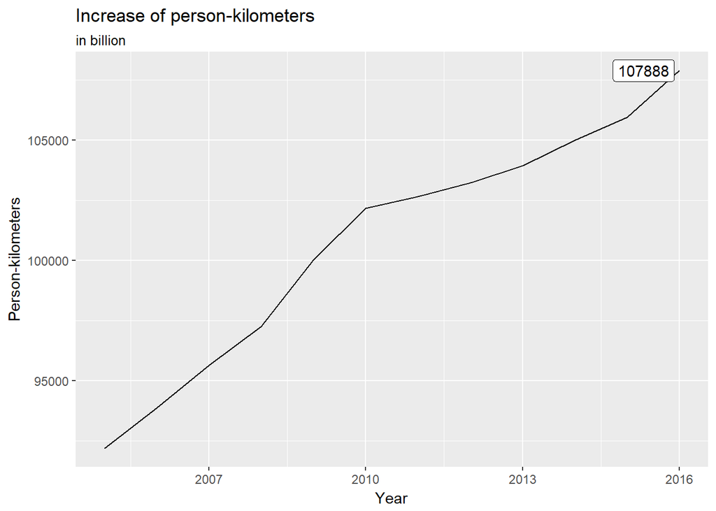

From this second graph, we can see that private car dominates. Almost 75% of the kilometers travelled in Switzerland are in a private car. Second is train which also represent a good chunk of the total.

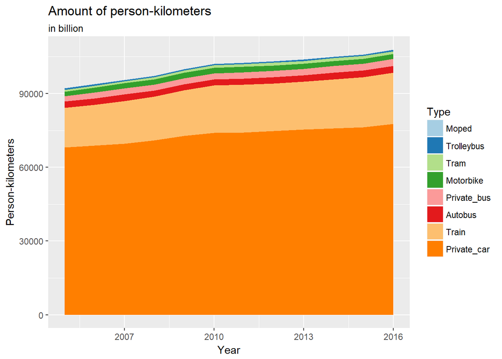

Again, we build a model to see the increase of each transport type.

```r
transport_model2 <- function(df) {lm(Pers_km ~ Year, data=df)}
#creates the models fitting functions

by_transport2 <- by_transport %>%
  mutate(model = purrr::map(data, transport_model2))
#create a new column for the nested models so that the related objects are stored together

by_transport2 <- by_transport2 %>%
  mutate(predictions = purrr::map2(data, model, add_predictions), resids = purrr::map2(data, model, add_residuals))
#create a new column for the nested predictions and residuals of the model

by_transport4 <- by_transport2 %>%
  mutate(tidy = purrr::map(model, broom::tidy)) %>%
  unnest(tidy, .drop = TRUE) %>%
  filter(term=="Year")
#unnesting the data. Retrieving the coefficients and their statistics
```

The first table again shows the predicition of the yearly increase for each transportation type. This time we see that the relative prediction of train to private cars is important.

Looking at the residuals, we arrive to the same conclusions as before. Some categories fluctuate more than others, but overal there’s no correlation.

Yearly increase

| Type | Prediction | STDE |
| --- | --- | --- |
| Train | 400.05 | 30.335 |
| Tram | 40.38 | 3.045 |
| Trolleybus | -1.38 | 0.711 |
| Autobus | 20.71 | 7.444 |
| Private_car | 854.99 | 55.613 |
| Private_bus | 41.44 | 5.748 |
| Motorbike | 6.29 | 12.807 |
| Moped | 1.80 | 0.403 |

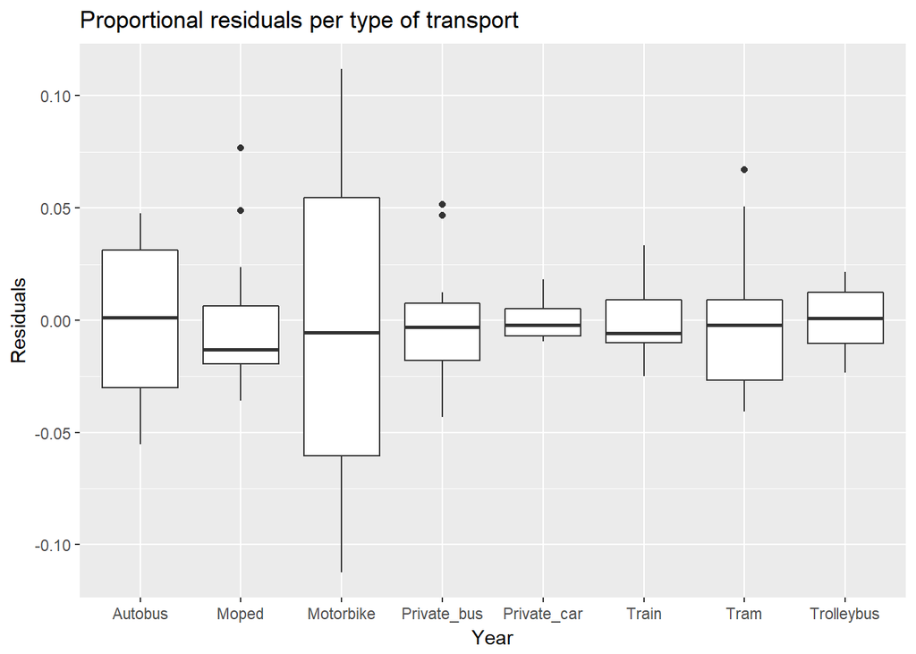

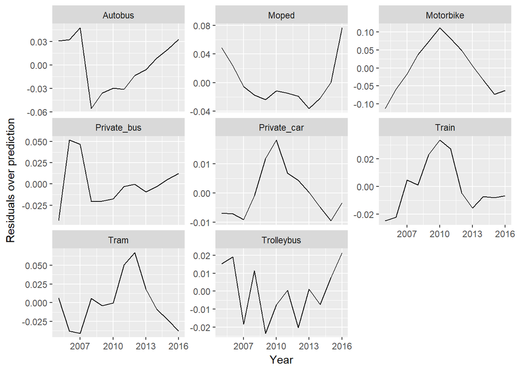

The results are similar to what we had for the vehicule-kilometer model.  
The one meaningful difference that is observable is in the graph of the relative growth of the different types. This graph works the same as the one before but this time with a meaningful information of customer behaviour. All variables are set to 100 for year 2005 and we see their relative evolution.  
We can see that train has gained 30% compared to the 20% of vehicule-kilometers in 11 year which means that the train are only a little bit more full than in 2005. Notable trend is that tram is comming strong even though it wasn’t particularly important for the vehicule-kilometers graph. Maybe a better management of the network led to more people using tram for a relatively lower number of trams put into work.

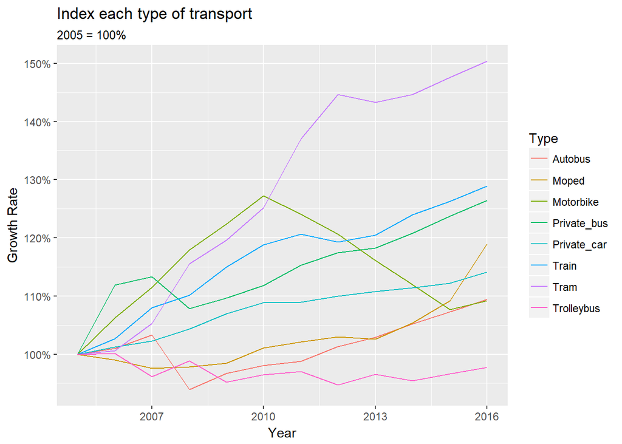

# 3 Conclusion

The number of passengers could double by 2050, international tourism is expected to go from 4 billion people to 16 billion by the same year. The growing demand for mobility raises serious questions and concerns, in particular for ecological and public health reasons. We have seen that Swiss people are travelling more and farther, and 73% of the time by car. Against all expectations, the proportion of individual transport put into circulation each year has never been so high (80% of road transport vehicles were light cars in 2017). It appears Switzerland has a lot to on the later, particularly in the passenger transport category where the vehicle fleet renewal is still largely dominated by polluting and fossil fuels.  
Even if ecological issues are, in our opinion, widely disseminated and present in consciences of the population (as the growing trend towards private electric vehicles shows) we believe that public authorities and transport companies in particular could act more effectively to encourage green mobility. We have seen that “green” fuels represent 1% to 0% of passenger transports vehicle fleet!  
They could for example implement bonus and malus policies on electric/hybrid motors and gasoline/diesel respectively or provide for the construction of charging stations and/or other systems in order to facilitate the implementation of an electric vehicle fleet. There is also a fairly good trade-off with natural gas propelled vehicles (which powers a majority of buses in France for example).

As for the behavioural aspect, we have seen that the infrastructure of green means of transportation are growing faster than for cars. This positive trend is supported by the fact that people tend to favour even more the green tranportation through their choice of transport.  
This is a good news that would mean that the government can now follow with their supply of infrastructure since the demand is here.  
However, there’s a black dot here again: people always travel more. It can also be seen in the data that were used on the second part of the report. Even if the means of transportation are greener, energy still needs to be produced which can never be 100% eco-friendly. Studies of the reason behind this increase could give interesting results and solution about teritorial mangagement so that people refrain from commuting too much.